# Predict Bike Sharing Demand with AutoGluon Template

## Project: Predict Bike Sharing Demand with AutoGluon

This notebook is a template with each step that you need to complete for the project.

Please fill in your code where there are explicit `?` markers in the notebook. You are welcome to add more cells and code as you see fit.

Once you have completed all the code implementations, please export your notebook as a HTML file so the reviews can view your code. Make sure you have all outputs correctly outputted.

`File-> Export Notebook As... -> Export Notebook as HTML`

There is a writeup to complete as well after all code implememtation is done. Please answer all questions and attach the necessary tables and charts. You can complete the writeup in either markdown or PDF.

Completing the code template and writeup template will cover all of the rubric points for this project.

The rubric contains "Stand Out Suggestions" for enhancing the project beyond the minimum requirements. The stand out suggestions are optional. If you decide to pursue the "stand out suggestions", you can include the code in this notebook and also discuss the results in the writeup file.

## Step 1: Create an account with Kaggle

### Create Kaggle Account and download API key

Below is example of steps to get the API username and key. Each student will have their own username and key.

1. Open account settings.

2. Scroll down to API and click Create New API Token.

3. Open up `kaggle.json` and use the username and key.


## Step 2: Download the Kaggle dataset using the kaggle python library

### Open up Sagemaker Studio and use starter template

1. Notebook should be using a `ml.t3.medium` instance (2 vCPU + 4 GiB)
2. Notebook should be using kernal: `Python 3 (MXNet 1.8 Python 3.7 CPU Optimized)`

### Install packages

```python
!pip install -U pip
!pip install -U setuptools wheel
!pip install torch==2.1.2 torchvision==0.16.2 --index-url https://download.pytorch.org/whl/cpu
!pip install autogluon
```

[output not shown]

[output cut: 232 more lines]

[output not shown]

```python
!pip install -q Kaggle
```

```
WARNING: Running pip as the 'root' user can result in broken permissions and conflicting behaviour with the system package manager. It is recommended to use a virtual environment instead: https://pip.pypa.io/warnings/venv
```

### Setup Kaggle API Key

```python
# create the .kaggle directory and an empty kaggle.json file
!mkdir ~/.kaggle
!cp kaggle.json ~/.kaggle/
# Authorize permissions for the json to act
!chmod 600 ~/.kaggle/kaggle.json
```

```python
# Fill in your user name and key from creating the kaggle account and API token file
import json
kaggle_username = "tanutomar25"
kaggle_key = "65db6ae3511c92badd376a48990e0fdb"

# Save API token the kaggle.json file
with open("/root/.kaggle/kaggle.json", "w") as f:
    f.write(json.dumps({"username": kaggle_username, "key": kaggle_key}))
```

### Download and explore dataset

### Go to the bike sharing demand competition and agree to the terms

```python
# Download the dataset, it will be in a .zip file so you'll need to unzip it as well.
!kaggle competitions download -c bike-sharing-demand
# If you already downloaded it you can use the -o command to overwrite the file
!unzip -o bike-sharing-demand.zip
```

```
Downloading bike-sharing-demand.zip to /root/cd0385-project-starter/project
Archive:  bike-sharing-demand.zip
  inflating: sampleSubmission.csv
  inflating: test.csv
  inflating: train.csv
```

```python
import pandas as pd
from autogluon.tabular import TabularPredictor
```

```python
# Create the train dataset in pandas by reading the csv
# Set the parsing of the datetime column so you can use some of the `dt` features in pandas later
train = pd.read_csv('train.csv',parse_dates=['datetime'])
train.head()
```

|  | datetime | season | holiday | workingday | weather | temp | atemp | humidity | windspeed | casual | registered | count |
| --- | --- | --- | --- | --- | --- | --- | --- | --- | --- | --- | --- | --- |
| 0 | 2011-01-01 00:00:00 | 1 | 0 | 0 | 1 | 9.84 | 14.395 | 81 | 0.0 | 3 | 13 | 16 |
| 1 | 2011-01-01 01:00:00 | 1 | 0 | 0 | 1 | 9.02 | 13.635 | 80 | 0.0 | 8 | 32 | 40 |
| 2 | 2011-01-01 02:00:00 | 1 | 0 | 0 | 1 | 9.02 | 13.635 | 80 | 0.0 | 5 | 27 | 32 |
| 3 | 2011-01-01 03:00:00 | 1 | 0 | 0 | 1 | 9.84 | 14.395 | 75 | 0.0 | 3 | 10 | 13 |
| 4 | 2011-01-01 04:00:00 | 1 | 0 | 0 | 1 | 9.84 | 14.395 | 75 | 0.0 | 0 | 1 | 1 |

```python
# Simple output of the train dataset to view some of the min/max/varition of the dataset features.
# Simple output of the train dataset to view some of the min/max/varition of the dataset features.
train.describe()
```

|  | datetime | season | holiday | workingday | weather | temp | atemp | humidity | windspeed | casual | registered | count |
| --- | --- | --- | --- | --- | --- | --- | --- | --- | --- | --- | --- | --- |
| count | 10886 | 10886.000000 | 10886.000000 | 10886.000000 | 10886.000000 | 10886.00000 | 10886.000000 | 10886.000000 | 10886.000000 | 10886.000000 | 10886.000000 | 10886.000000 |
| mean | 2011-12-27 05:56:22.399411968 | 2.506614 | 0.028569 | 0.680875 | 1.418427 | 20.23086 | 23.655084 | 61.886460 | 12.799395 | 36.021955 | 155.552177 | 191.574132 |
| min | 2011-01-01 00:00:00 | 1.000000 | 0.000000 | 0.000000 | 1.000000 | 0.82000 | 0.760000 | 0.000000 | 0.000000 | 0.000000 | 0.000000 | 1.000000 |
| 25% | 2011-07-02 07:15:00 | 2.000000 | 0.000000 | 0.000000 | 1.000000 | 13.94000 | 16.665000 | 47.000000 | 7.001500 | 4.000000 | 36.000000 | 42.000000 |
| 50% | 2012-01-01 20:30:00 | 3.000000 | 0.000000 | 1.000000 | 1.000000 | 20.50000 | 24.240000 | 62.000000 | 12.998000 | 17.000000 | 118.000000 | 145.000000 |
| 75% | 2012-07-01 12:45:00 | 4.000000 | 0.000000 | 1.000000 | 2.000000 | 26.24000 | 31.060000 | 77.000000 | 16.997900 | 49.000000 | 222.000000 | 284.000000 |
| max | 2012-12-19 23:00:00 | 4.000000 | 1.000000 | 1.000000 | 4.000000 | 41.00000 | 45.455000 | 100.000000 | 56.996900 | 367.000000 | 886.000000 | 977.000000 |
| std | NaN | 1.116174 | 0.166599 | 0.466159 | 0.633839 | 7.79159 | 8.474601 | 19.245033 | 8.164537 | 49.960477 | 151.039033 | 181.144454 |

```python
# Create the test pandas dataframe in pandas by reading the csv, remember to parse the datetime!
test = pd.read_csv('test.csv',parse_dates=['datetime'])
test.head()
```

|  | datetime | season | holiday | workingday | weather | temp | atemp | humidity | windspeed |
| --- | --- | --- | --- | --- | --- | --- | --- | --- | --- |
| 0 | 2011-01-20 00:00:00 | 1 | 0 | 1 | 1 | 10.66 | 11.365 | 56 | 26.0027 |
| 1 | 2011-01-20 01:00:00 | 1 | 0 | 1 | 1 | 10.66 | 13.635 | 56 | 0.0000 |
| 2 | 2011-01-20 02:00:00 | 1 | 0 | 1 | 1 | 10.66 | 13.635 | 56 | 0.0000 |
| 3 | 2011-01-20 03:00:00 | 1 | 0 | 1 | 1 | 10.66 | 12.880 | 56 | 11.0014 |
| 4 | 2011-01-20 04:00:00 | 1 | 0 | 1 | 1 | 10.66 | 12.880 | 56 | 11.0014 |

```python
# Same thing as train and test dataset
submission = pd.read_csv('sampleSubmission.csv')
submission.head()
```

|  | datetime | count |
| --- | --- | --- |
| 0 | 2011-01-20 00:00:00 | 0 |
| 1 | 2011-01-20 01:00:00 | 0 |
| 2 | 2011-01-20 02:00:00 | 0 |
| 3 | 2011-01-20 03:00:00 | 0 |
| 4 | 2011-01-20 04:00:00 | 0 |

## Step 4: Exploratory Data Analysis

```python
train.info()
```

```
<class 'pandas.core.frame.DataFrame'>
RangeIndex: 10886 entries, 0 to 10885
Data columns (total 12 columns):
 #   Column      Non-Null Count  Dtype
---  ------      --------------  -----
 0   datetime    10886 non-null  datetime64[ns]
 1   season      10886 non-null  int64
 2   holiday     10886 non-null  int64
 3   workingday  10886 non-null  int64
 4   weather     10886 non-null  int64
 5   temp        10886 non-null  float64
 6   atemp       10886 non-null  float64
 7   humidity    10886 non-null  int64
 8   windspeed   10886 non-null  float64
 9   casual      10886 non-null  int64
 10  registered  10886 non-null  int64
 11  count       10886 non-null  int64
dtypes: datetime64[ns](1), float64(3), int64(8)
memory usage: 1020.7 KB
```

```python
train['season'].value_counts()
```

```
season
4    2734
2    2733
3    2733
1    2686
Name: count, dtype: int64
```

```python
train['holiday'].value_counts()
```

```
holiday
0    10575
1      311
Name: count, dtype: int64
```

```python
train['weather'].value_counts()
```

```
weather
1    7192
2    2834
3     859
4       1
Name: count, dtype: int64
```

```python
corr=train.corr(numeric_only=True)
corr
```

[output not shown]

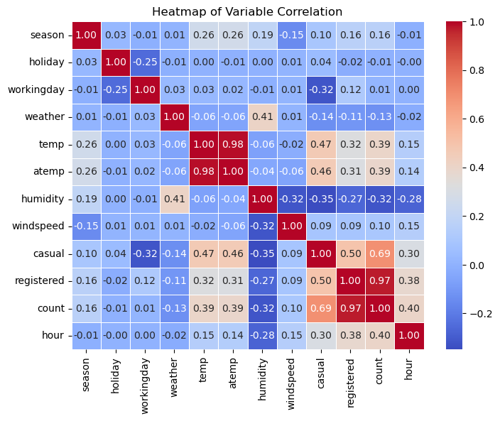

```python
import matplotlib.pyplot as plt
import seaborn as sns
# Create a heatmap from the correlation matrix
plt.figure(figsize=(8, 6))  # Set figure size
sns.heatmap(corr, annot=True, cmap='coolwarm', fmt=".2f", linewidths=.5)
plt.title('Heatmap of Variable Correlation')
plt.show()
```

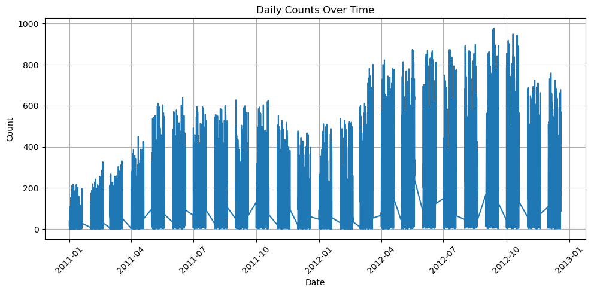

```python
plt.figure(figsize=(10, 5))  # Set the figure size
plt.plot(train['datetime'], train['count'])  # Line plot

# Adding title and labels
plt.title('Daily Counts Over Time')
plt.xlabel('Date')
plt.ylabel('Count')

# Optional: Rotate date labels for better readability
plt.xticks(rotation=45)

plt.grid(True)  # Enable grid
plt.tight_layout()  # Adjust layout
plt.show()
```

```
array([[<Axes: title={'center': 'datetime'}>,
        <Axes: title={'center': 'season'}>,
        <Axes: title={'center': 'holiday'}>,
        <Axes: title={'center': 'workingday'}>],
       [<Axes: title={'center': 'weather'}>,
        <Axes: title={'center': 'temp'}>,
        <Axes: title={'center': 'atemp'}>,
        <Axes: title={'center': 'humidity'}>],
       [<Axes: title={'center': 'windspeed'}>,
        <Axes: title={'center': 'casual'}>,
        <Axes: title={'center': 'registered'}>,
        <Axes: title={'center': 'count'}>],
       [<Axes: title={'center': 'hour'}>, <Axes: >, <Axes: >, <Axes: >]],
      dtype=object)
```

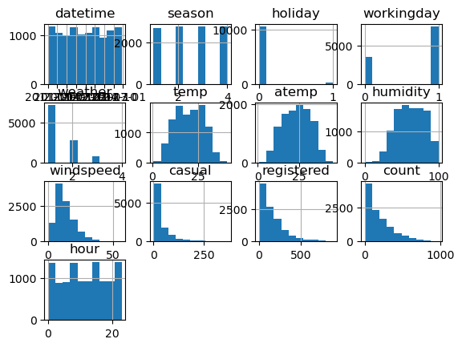

```python
train.hist()
```

```python
train_initial = train.copy(deep=True)
```

```python
test_initial = test.copy(deep=True)
```

```python
train_initial.drop(['casual','registered'],inplace=True, axis=1)
```

```python
train_initial.info()
```

[output not shown]

```python
train_initial.drop(['datetime'],inplace=True, axis=1)
```

```python
train_initial.info()
```

```
<class 'pandas.core.frame.DataFrame'>
RangeIndex: 10886 entries, 0 to 10885
Data columns (total 10 columns):
 #   Column      Non-Null Count  Dtype
---  ------      --------------  -----
 0   season      10886 non-null  int64
 1   holiday     10886 non-null  int64
 2   workingday  10886 non-null  int64
 3   weather     10886 non-null  int64
 4   temp        10886 non-null  float64
 5   atemp       10886 non-null  float64
 6   humidity    10886 non-null  int64
 7   windspeed   10886 non-null  float64
 8   count       10886 non-null  int64
 9   hour        10886 non-null  int32
dtypes: float64(3), int32(1), int64(6)
memory usage: 808.1 KB
```

```python
test_initial.drop(['datetime'],inplace=True,axis=1)
```

```python
test_initial.info()
```

```
<class 'pandas.core.frame.DataFrame'>
RangeIndex: 6493 entries, 0 to 6492
Data columns (total 9 columns):
 #   Column      Non-Null Count  Dtype
---  ------      --------------  -----
 0   season      6493 non-null   int64
 1   holiday     6493 non-null   int64
 2   workingday  6493 non-null   int64
 3   weather     6493 non-null   int64
 4   temp        6493 non-null   float64
 5   atemp       6493 non-null   float64
 6   humidity    6493 non-null   int64
 7   windspeed   6493 non-null   float64
 8   hour        6493 non-null   int32
dtypes: float64(3), int32(1), int64(5)
memory usage: 431.3 KB
```

## Step 3: Train a model using AutoGluon’s Tabular Prediction

Requirements:

- We are prediting `count`, so it is the label we are setting.
- Ignore `casual` and `registered` columns as they are also not present in the test dataset.
- Use the `root_mean_squared_error` as the metric to use for evaluation.
- Set a time limit of 10 minutes (600 seconds).
- Use the preset `best_quality` to focus on creating the best model.

```python
predictor_initial = TabularPredictor(label="count",problem_type="regression", eval_metric="rmse", path="autogn_initial" ).fit(
    train_data=train_initial,
    time_limit=600,
    presets="best_quality",
)
```

```
Presets specified: ['best_quality']
Setting dynamic_stacking from 'auto' to True. Reason: Enable dynamic_stacking when use_bag_holdout is disabled. (use_bag_holdout=False)
Stack configuration (auto_stack=True): num_stack_levels=1, num_bag_folds=8, num_bag_sets=1
Dynamic stacking is enabled (dynamic_stacking=True). AutoGluon will try to determine whether the input data is affected by stacked overfitting and enable or disable stacking as a consequence.
Detecting stacked overfitting by sub-fitting AutoGluon on the input data. That is, copies of AutoGluon will be sub-fit on subset(s) of the data. Then, the holdout validation data is used to detect stacked overfitting.
Sub-fit(s) time limit is: 600 seconds.
Starting holdout-based sub-fit for dynamic stacking. Context path is: autogn_initial/ds_sub_fit/sub_fit_ho.
Running the sub-fit in a ray process to avoid memory leakage.
Spend 185 seconds for the sub-fit(s) during dynamic stacking.
Time left for full fit of AutoGluon: 415 seconds.
Starting full fit now with num_stack_levels 1.
Beginning AutoGluon training ... Time limit = 415s
AutoGluon will save models to "autogn_initial"
=================== System Info ===================
AutoGluon Version:  1.1.0
Python Version:     3.10.6
Operating System:   Linux
Platform Machine:   x86_64
Platform Version:   #1 SMP Sat Mar 23 09:49:55 UTC 2024
CPU Count:          2
Memory Avail:       1.75 GB / 3.78 GB (46.4%)
Disk Space Avail:   8589934590.95 GB / 8589934592.00 GB (100.0%)
===================================================
Train Data Rows:    10886
Train Data Columns: 9
Label Column:       count
Problem Type:       regression
Preprocessing data ...
Using Feature Generators to preprocess the data ...
Fitting AutoMLPipelineFeatureGenerator...
	Available Memory:                    1796.31 MB
	Train Data (Original)  Memory Usage: 0.71 MB (0.0% of available memory)
	Inferring data type of each feature based on column values. Set feature_metadata_in to manually specify special dtypes of the features.
	Stage 1 Generators:
		Fitting AsTypeFeatureGenerator...
			Note: Converting 2 features to boolean dtype as they only contain 2 unique values.
	Stage 2 Generators:
		Fitting FillNaFeatureGenerator...
	Stage 3 Generators:
		Fitting IdentityFeatureGenerator...
```

[output cut: 80 more lines]

```
	Fitting 8 child models (S1F1 - S1F8) | Fitting with ParallelLocalFoldFittingStrategy (2 workers, per: cpus=1, gpus=0, memory=0.48%)
	-64.7958	 = Validation score   (-root_mean_squared_error)
	28.06s	 = Training   runtime
	0.11s	 = Validation runtime
Fitting model: RandomForestMSE_BAG_L2 ... Training model for up to 35.27s of the 35.21s of remaining time.
	-64.7924	 = Validation score   (-root_mean_squared_error)
	46.0s	 = Training   runtime
	0.91s	 = Validation runtime
Fitting model: WeightedEnsemble_L3 ... Training model for up to 360.0s of the -16.92s of remaining time.
	Ensemble Weights: {'RandomForestMSE_BAG_L2': 0.32, 'CatBoost_BAG_L1': 0.28, 'LightGBMXT_BAG_L2': 0.16, 'LightGBMXT_BAG_L1': 0.08, 'LightGBM_BAG_L2': 0.08, 'LightGBM_BAG_L1': 0.04, 'RandomForestMSE_BAG_L1': 0.04}
	-63.7912	 = Validation score   (-root_mean_squared_error)
	0.07s	 = Training   runtime
	0.0s	 = Validation runtime
AutoGluon training complete, total runtime = 432.23s ... Best model: "WeightedEnsemble_L3"
TabularPredictor saved. To load, use: predictor = TabularPredictor.load("autogn_initial")
```

```python
predictor_initial.fit_summary()
```

```
*** Summary of fit() ***
Estimated performance of each model:
                     model   score_val              eval_metric  pred_time_val    fit_time  pred_time_val_marginal  fit_time_marginal  stack_level  can_infer  fit_order
0      WeightedEnsemble_L3  -63.791227  root_mean_squared_error      14.952847  388.283173                0.000643           0.073950            3       True         13
1      WeightedEnsemble_L2  -64.212527  root_mean_squared_error      12.399773  229.442281                0.000967           0.046374            2       True          9
2        LightGBMXT_BAG_L2  -64.638896  root_mean_squared_error      13.927373  314.147418                0.221060          28.679869            2       True         10
3   RandomForestMSE_BAG_L2  -64.792403  root_mean_squared_error      14.616765  331.471045                0.910452          46.003496            2       True         12
4          LightGBM_BAG_L2  -64.795766  root_mean_squared_error      13.820692  313.525858                0.114378          28.058309            2       True         11
5          CatBoost_BAG_L1  -64.809919  root_mean_squared_error       0.110232  111.449080                0.110232         111.449080            1       True          6
6          LightGBM_BAG_L1  -65.804640  root_mean_squared_error       1.867998   35.056170                1.867998          35.056170            1       True          4
7        LightGBMXT_BAG_L1  -66.251809  root_mean_squared_error       9.525338   70.645670                9.525338          70.645670            1       True          3
8     ExtraTreesMSE_BAG_L1  -68.985679  root_mean_squared_error       0.572249    5.049309                0.572249           5.049309            1       True          7
9   RandomForestMSE_BAG_L1  -69.488359  root_mean_squared_error       0.895238   12.244987                0.895238          12.244987            1       True          5
10  NeuralNetFastAI_BAG_L1 -119.209644  root_mean_squared_error       0.399650   50.944251                0.399650          50.944251            1       True          8
11   KNeighborsDist_BAG_L1 -121.258519  root_mean_squared_error       0.188376    0.034665                0.188376           0.034665            1       True          2
12   KNeighborsUnif_BAG_L1 -122.586594  root_mean_squared_error       0.147233    0.043417                0.147233           0.043417            1       True          1
Number of models trained: 13
Types of models trained:
{'WeightedEnsembleModel', 'StackerEnsembleModel_LGB', 'StackerEnsembleModel_NNFastAiTabular', 'StackerEnsembleModel_RF', 'StackerEnsembleModel_CatBoost', 'StackerEnsembleModel_KNN', 'StackerEnsembleModel_XT'}
Bagging used: True  (with 8 folds)
Multi-layer stack-ensembling used: True  (with 3 levels)
Feature Metadata (Processed):
(raw dtype, special dtypes):
('float', [])     : 3 | ['temp', 'atemp', 'windspeed']
('int', [])       : 4 | ['season', 'weather', 'humidity', 'hour']
('int', ['bool']) : 2 | ['holiday', 'workingday']
Plot summary of models saved to file: autogn_initialSummaryOfModels.html
*** End of fit() summary ***
```

[output not shown]

[output cut: 114 more lines]

```

     stack_level  can_infer  fit_order
 0             3       True         13
 1             2       True          9
 2             2       True         10
 3             2       True         12
 4             2       True         11
 5             1       True          6
 6             1       True          4
 7             1       True          3
 8             1       True          7
 9             1       True          5
 10            1       True          8
 11            1       True          2
 12            1       True          1  }
```

```python
leaderboard = predictor_initial.leaderboard(silent=True)
```

```python
model_names = leaderboard['model']
rmse_values = leaderboard['score_val']
```

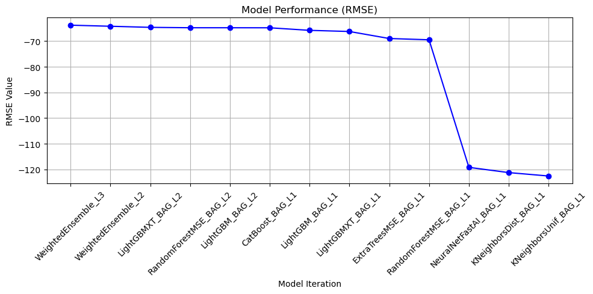

```python
import matplotlib.pyplot as plt

plt.figure(figsize=(10, 5))
plt.plot(model_names, rmse_values, marker='o', linestyle='-', color='b')
plt.title('Model Performance (RMSE)')
plt.xlabel('Model Iteration')
plt.ylabel('RMSE Value')
plt.xticks(rotation=45)
plt.grid(True)
plt.tight_layout()
plt.show()
```

```python
predictions_initial = predictor_initial.predict(test_initial)
predictions_initial.head()
```

```
0    15.218033
1     6.044022
2     3.240554
3     1.742274
4     1.757047
Name: count, dtype: float32
```

```python
predictions_initial.describe()
```

```
count    6493.000000
mean      187.632034
std       165.931290
min        -5.035999
25%        45.440704
50%       149.915161
75%       277.925323
max       786.924561
Name: count, dtype: float64
```

```python
# How many negative values do we have?
negative_count = (predictions_initial < 0).sum()
negative_count
```

```
44
```

```python
initial_predictions = predictions_initial.clip(lower=0)
```

```python
submission_initial=submission.copy(deep=True)
```

```python
submission_initial["count"] = initial_predictions
submission_initial.to_csv("submission_initial.csv", index=False)
```

### Submit to Kaggle

```python
!kaggle competitions submit -c bike-sharing-demand -f submission_initial.csv -m "first raw submission"
```

```
Successfully submitted to Bike Sharing Demand
```

```python
!kaggle competitions submissions -c bike-sharing-demand | tail -n +1 | head -n 6
```

```
fileName                date                 description           status    publicScore  privateScore
----------------------  -------------------  --------------------  --------  -----------  ------------
submission_initial.csv  2024-04-29 19:26:03  first raw submission  complete  0.52082      0.52082
```

#### Initial score of : 0.52

## Step 5: Rerun the model with the same settings as before, just with more features

## Featur Eng.

```python
train['hour']=train['datetime'].dt.hour
```

```python
test['hour']=test['datetime'].dt.hour
```

```python
bins = [0.82, 10, 30, 41]
labels = ['Cold', 'Mild', 'Hot']
train['temperature_category'] = pd.cut(train['temp'], bins=bins, labels=labels, include_lowest=True)
```

```python
train['temperature_category'].value_counts()
```

```
temperature_category
Mild    8383
Cold    1259
Hot     1244
Name: count, dtype: int64
```

```python
test['temperature_category'] = pd.cut(test['temp'], bins=bins, labels=labels, include_lowest=True)
```

```python
bins = [0, 25, max(train['windspeed']) + 1]
labels = ['Mild Wind', 'Very Windy']
train['wind_category'] = pd.cut(train['windspeed'], bins=bins, labels=labels, include_lowest=True, right=False)
```

```python
train['wind_category'].value_counts()
```

```
wind_category
Mild Wind     10037
Very Windy      849
Name: count, dtype: int64
```

```python
test['wind_category'] = pd.cut(test['windspeed'], bins=bins, labels=labels, include_lowest=True, right=False)
```

```python
bins = [0, 65, 100]  # Assumed humidity ranges from 0% to 100%
labels = ['Not Humid', 'Very Humid']
train['humidity_category'] = pd.cut(train['humidity'], bins=bins, labels=labels, include_lowest=True)
```

```python
train['humidity_category'].value_counts()
```

```
humidity_category
Not Humid     6094
Very Humid    4792
Name: count, dtype: int64
```

```python
test['humidity_category'] = pd.cut(test['humidity'], bins=bins, labels=labels, include_lowest=True)
```

```python
train.info()
```

```
<class 'pandas.core.frame.DataFrame'>
RangeIndex: 10886 entries, 0 to 10885
Data columns (total 16 columns):
 #   Column                Non-Null Count  Dtype
---  ------                --------------  -----
 0   datetime              10886 non-null  datetime64[ns]
 1   season                10886 non-null  int64
 2   holiday               10886 non-null  int64
 3   workingday            10886 non-null  int64
 4   weather               10886 non-null  int64
 5   temp                  10886 non-null  float64
 6   atemp                 10886 non-null  float64
 7   humidity              10886 non-null  int64
 8   windspeed             10886 non-null  float64
 9   casual                10886 non-null  int64
 10  registered            10886 non-null  int64
 11  count                 10886 non-null  int64
 12  hour                  10886 non-null  int32
 13  temperature_category  10886 non-null  category
 14  wind_category         10886 non-null  category
 15  humidity_category     10886 non-null  category
dtypes: category(3), datetime64[ns](1), float64(3), int32(1), int64(8)
memory usage: 1.1 MB
```

```python
def categorize_rush_hour(hour):
    if 7 <= hour <= 9:
        return 'Morning Rush Hour'
    elif 11 <= hour <= 13:  # Adjusted to include 1pm as per your range
        return 'Lunch Rush Hour'
    elif 17 <= hour <= 18:
        return 'Evening Rush Hour'
    else:
        return 'Night'
```

```python
train['hour_category'] = train['hour'].apply(categorize_rush_hour)
```

```python
train['hour_category'].value_counts()
```

```
hour_category
Night                7242
Lunch Rush Hour      1367
Morning Rush Hour    1365
Evening Rush Hour     912
Name: count, dtype: int64
```

```python
test['hour_category'] = test['hour'].apply(categorize_rush_hour)
```

## Feature Encoding

```python
train_modified = pd.get_dummies(train, columns=['temperature_category', 'wind_category', 'humidity_category','hour_category','weather','season'],dtype=int)
```

```python
test_modified = pd.get_dummies(test, columns=['temperature_category', 'wind_category', 'humidity_category','hour_category','weather','season'],dtype=int)
```

```python
train_modified
```

|  | datetime | holiday | workingday | temp | atemp | humidity | windspeed | casual | registered | count | ... | hour_category_Morning Rush Hour | hour_category_Night | weather_1 | weather_2 | weather_3 | weather_4 | season_1 | season_2 | season_3 | season_4 |
| --- | --- | --- | --- | --- | --- | --- | --- | --- | --- | --- | --- | --- | --- | --- | --- | --- | --- | --- | --- | --- | --- |
| 0 | 2011-01-01 00:00:00 | 0 | 0 | 9.84 | 14.395 | 81 | 0.0000 | 3 | 13 | 16 | ... | 0 | 1 | 1 | 0 | 0 | 0 | 1 | 0 | 0 | 0 |
| 1 | 2011-01-01 01:00:00 | 0 | 0 | 9.02 | 13.635 | 80 | 0.0000 | 8 | 32 | 40 | ... | 0 | 1 | 1 | 0 | 0 | 0 | 1 | 0 | 0 | 0 |
| 2 | 2011-01-01 02:00:00 | 0 | 0 | 9.02 | 13.635 | 80 | 0.0000 | 5 | 27 | 32 | ... | 0 | 1 | 1 | 0 | 0 | 0 | 1 | 0 | 0 | 0 |
| 3 | 2011-01-01 03:00:00 | 0 | 0 | 9.84 | 14.395 | 75 | 0.0000 | 3 | 10 | 13 | ... | 0 | 1 | 1 | 0 | 0 | 0 | 1 | 0 | 0 | 0 |
| 4 | 2011-01-01 04:00:00 | 0 | 0 | 9.84 | 14.395 | 75 | 0.0000 | 0 | 1 | 1 | ... | 0 | 1 | 1 | 0 | 0 | 0 | 1 | 0 | 0 | 0 |
| ... | ... | ... | ... | ... | ... | ... | ... | ... | ... | ... | ... | ... | ... | ... | ... | ... | ... | ... | ... | ... | ... |
| 10881 | 2012-12-19 19:00:00 | 0 | 1 | 15.58 | 19.695 | 50 | 26.0027 | 7 | 329 | 336 | ... | 0 | 1 | 1 | 0 | 0 | 0 | 0 | 0 | 0 | 1 |
| 10882 | 2012-12-19 20:00:00 | 0 | 1 | 14.76 | 17.425 | 57 | 15.0013 | 10 | 231 | 241 | ... | 0 | 1 | 1 | 0 | 0 | 0 | 0 | 0 | 0 | 1 |
| 10883 | 2012-12-19 21:00:00 | 0 | 1 | 13.94 | 15.910 | 61 | 15.0013 | 4 | 164 | 168 | ... | 0 | 1 | 1 | 0 | 0 | 0 | 0 | 0 | 0 | 1 |
| 10884 | 2012-12-19 22:00:00 | 0 | 1 | 13.94 | 17.425 | 61 | 6.0032 | 12 | 117 | 129 | ... | 0 | 1 | 1 | 0 | 0 | 0 | 0 | 0 | 0 | 1 |
| 10885 | 2012-12-19 23:00:00 | 0 | 1 | 13.12 | 16.665 | 66 | 8.9981 | 4 | 84 | 88 | ... | 0 | 1 | 1 | 0 | 0 | 0 | 0 | 0 | 0 | 1 |

10886 rows × 30 columns

```python
train_modified.drop(columns=['temp','windspeed','humidity','hour'],inplace=True)
```

```python
test_modified.drop(columns=['temp','windspeed','humidity','hour'],inplace=True)
```

```python
train_modified.info()
```

```
<class 'pandas.core.frame.DataFrame'>
RangeIndex: 10886 entries, 0 to 10885
Data columns (total 26 columns):
 #   Column                           Non-Null Count  Dtype
---  ------                           --------------  -----
 0   datetime                         10886 non-null  datetime64[ns]
 1   holiday                          10886 non-null  int64
 2   workingday                       10886 non-null  int64
 3   atemp                            10886 non-null  float64
 4   casual                           10886 non-null  int64
 5   registered                       10886 non-null  int64
 6   count                            10886 non-null  int64
 7   temperature_category_Cold        10886 non-null  int64
 8   temperature_category_Mild        10886 non-null  int64
 9   temperature_category_Hot         10886 non-null  int64
```

[output cut: 18 more lines]

```python
train_modified.drop(columns=['registered','casual','datetime'],inplace=True)
```

```python
test_modified.drop(columns=['datetime'],inplace=True)
```

```python
train_modified.info()
```

```
<class 'pandas.core.frame.DataFrame'>
RangeIndex: 10886 entries, 0 to 10885
Data columns (total 23 columns):
 #   Column                           Non-Null Count  Dtype
---  ------                           --------------  -----
 0   holiday                          10886 non-null  int64
 1   workingday                       10886 non-null  int64
 2   atemp                            10886 non-null  float64
 3   count                            10886 non-null  int64
 4   temperature_category_Cold        10886 non-null  int64
 5   temperature_category_Mild        10886 non-null  int64
 6   temperature_category_Hot         10886 non-null  int64
 7   wind_category_Mild Wind          10886 non-null  int64
 8   wind_category_Very Windy         10886 non-null  int64
 9   humidity_category_Not Humid      10886 non-null  int64
 10  humidity_category_Very Humid     10886 non-null  int64
 11  hour_category_Evening Rush Hour  10886 non-null  int64
 12  hour_category_Lunch Rush Hour    10886 non-null  int64
 13  hour_category_Morning Rush Hour  10886 non-null  int64
 14  hour_category_Night              10886 non-null  int64
 15  weather_1                        10886 non-null  int64
 16  weather_2                        10886 non-null  int64
 17  weather_3                        10886 non-null  int64
 18  weather_4                        10886 non-null  int64
 19  season_1                         10886 non-null  int64
 20  season_2                         10886 non-null  int64
 21  season_3                         10886 non-null  int64
 22  season_4                         10886 non-null  int64
dtypes: float64(1), int64(22)
memory usage: 1.9 MB
```

```python
test_modified.info()
```

```
<class 'pandas.core.frame.DataFrame'>
RangeIndex: 6493 entries, 0 to 6492
Data columns (total 22 columns):
 #   Column                           Non-Null Count  Dtype
---  ------                           --------------  -----
 0   holiday                          6493 non-null   int64
 1   workingday                       6493 non-null   int64
 2   atemp                            6493 non-null   float64
 3   temperature_category_Cold        6493 non-null   int64
 4   temperature_category_Mild        6493 non-null   int64
 5   temperature_category_Hot         6493 non-null   int64
 6   wind_category_Mild Wind          6493 non-null   int64
 7   wind_category_Very Windy         6493 non-null   int64
 8   humidity_category_Not Humid      6493 non-null   int64
 9   humidity_category_Very Humid     6493 non-null   int64
 10  hour_category_Evening Rush Hour  6493 non-null   int64
 11  hour_category_Lunch Rush Hour    6493 non-null   int64
 12  hour_category_Morning Rush Hour  6493 non-null   int64
 13  hour_category_Night              6493 non-null   int64
 14  weather_1                        6493 non-null   int64
 15  weather_2                        6493 non-null   int64
 16  weather_3                        6493 non-null   int64
 17  weather_4                        6493 non-null   int64
 18  season_1                         6493 non-null   int64
 19  season_2                         6493 non-null   int64
 20  season_3                         6493 non-null   int64
 21  season_4                         6493 non-null   int64
dtypes: float64(1), int64(21)
memory usage: 1.1 MB
```

### Model with new Features

```python
from autogluon.tabular import TabularPredictor
```

```python
predictor = TabularPredictor(label="count",problem_type="regression", eval_metric="rmse").fit(
    train_data=train_modified,
    time_limit=600,
    presets="best_quality")
```

```
No path specified. Models will be saved in: "AutogluonModels/ag-20240429_181606"
Presets specified: ['best_quality']
Setting dynamic_stacking from 'auto' to True. Reason: Enable dynamic_stacking when use_bag_holdout is disabled. (use_bag_holdout=False)
Stack configuration (auto_stack=True): num_stack_levels=1, num_bag_folds=8, num_bag_sets=1
Dynamic stacking is enabled (dynamic_stacking=True). AutoGluon will try to determine whether the input data is affected by stacked overfitting and enable or disable stacking as a consequence.
Detecting stacked overfitting by sub-fitting AutoGluon on the input data. That is, copies of AutoGluon will be sub-fit on subset(s) of the data. Then, the holdout validation data is used to detect stacked overfitting.
Sub-fit(s) time limit is: 600 seconds.
Starting holdout-based sub-fit for dynamic stacking. Context path is: AutogluonModels/ag-20240429_181606/ds_sub_fit/sub_fit_ho.
2024-04-29 18:16:06,857	INFO util.py:154 -- Outdated packages:
  ipywidgets==7.6.5 found, needs ipywidgets>=8
Run `pip install -U ipywidgets`, then restart the notebook server for rich notebook output.
Running the sub-fit in a ray process to avoid memory leakage.
Spend 204 seconds for the sub-fit(s) during dynamic stacking.
Time left for full fit of AutoGluon: 396 seconds.
Starting full fit now with num_stack_levels 0.
Beginning AutoGluon training ... Time limit = 396s
AutoGluon will save models to "AutogluonModels/ag-20240429_181606"
=================== System Info ===================
AutoGluon Version:  1.1.0
Python Version:     3.10.6
Operating System:   Linux
Platform Machine:   x86_64
Platform Version:   #1 SMP Sat Mar 23 09:49:55 UTC 2024
CPU Count:          2
Memory Avail:       1.81 GB / 3.78 GB (48.0%)
Disk Space Avail:   8589934592.00 GB / 8589934592.00 GB (100.0%)
===================================================
Train Data Rows:    10886
Train Data Columns: 22
Label Column:       count
Problem Type:       regression
Preprocessing data ...
Using Feature Generators to preprocess the data ...
Fitting AutoMLPipelineFeatureGenerator...
	Available Memory:                    1853.49 MB
	Train Data (Original)  Memory Usage: 1.83 MB (0.1% of available memory)
	Inferring data type of each feature based on column values. Set feature_metadata_in to manually specify special dtypes of the features.
	Stage 1 Generators:
		Fitting AsTypeFeatureGenerator...
			Note: Converting 21 features to boolean dtype as they only contain 2 unique values.
```

[output cut: 72 more lines]

```
	-109.3559	 = Validation score   (-root_mean_squared_error)
	19.01s	 = Training   runtime
	0.21s	 = Validation runtime
Fitting model: NeuralNetTorch_BAG_L1 ... Training model for up to 108.06s of the 108.04s of remaining time.
	Fitting 8 child models (S1F1 - S1F8) | Fitting with ParallelLocalFoldFittingStrategy (2 workers, per: cpus=1, gpus=0, memory=0.10%)
	-112.5929	 = Validation score   (-root_mean_squared_error)
	112.93s	 = Training   runtime
	0.16s	 = Validation runtime
Fitting model: WeightedEnsemble_L2 ... Training model for up to 360.0s of the -11.21s of remaining time.
	Ensemble Weights: {'CatBoost_BAG_L1': 0.375, 'RandomForestMSE_BAG_L1': 0.208, 'NeuralNetFastAI_BAG_L1': 0.167, 'LightGBMXT_BAG_L1': 0.125, 'ExtraTreesMSE_BAG_L1': 0.042, 'XGBoost_BAG_L1': 0.042, 'NeuralNetTorch_BAG_L1': 0.042}
	-107.9704	 = Validation score   (-root_mean_squared_error)
	0.05s	 = Training   runtime
	0.0s	 = Validation runtime
AutoGluon training complete, total runtime = 407.49s ... Best model: "WeightedEnsemble_L2"
TabularPredictor saved. To load, use: predictor = TabularPredictor.load("AutogluonModels/ag-20240429_181606")
```

### Review AutoGluon's training run with ranking of models that did the best.

```python
predictor.fit_summary()
```

```
*** Summary of fit() ***
Estimated performance of each model:
                     model   score_val              eval_metric  pred_time_val    fit_time  pred_time_val_marginal  fit_time_marginal  stack_level  can_infer  fit_order
0      WeightedEnsemble_L2 -107.970377  root_mean_squared_error       3.984732  345.201550                0.001716           0.049110            2       True         11
1          CatBoost_BAG_L1 -108.770829  root_mean_squared_error       0.064017   41.393702                0.064017          41.393702            1       True          6
2        LightGBMXT_BAG_L1 -109.033914  root_mean_squared_error       1.336008   34.108179                1.336008          34.108179            1       True          3
3           XGBoost_BAG_L1 -109.355918  root_mean_squared_error       0.213954   19.006731                0.213954          19.006731            1       True          9
4          LightGBM_BAG_L1 -109.451542  root_mean_squared_error       0.528717   29.066205                0.528717          29.066205            1       True          4
5   NeuralNetFastAI_BAG_L1 -110.210307  root_mean_squared_error       0.376909  124.171890                0.376909         124.171890            1       True          8
6    NeuralNetTorch_BAG_L1 -112.592934  root_mean_squared_error       0.160218  112.930611                0.160218         112.930611            1       True         10
7     ExtraTreesMSE_BAG_L1 -113.025465  root_mean_squared_error       0.829511    6.005287                0.829511           6.005287            1       True          7
8   RandomForestMSE_BAG_L1 -113.122076  root_mean_squared_error       1.002399    7.536041                1.002399           7.536041            1       True          5
9    KNeighborsDist_BAG_L1 -181.165806  root_mean_squared_error       0.097079    0.021751                0.097079           0.021751            1       True          2
10   KNeighborsUnif_BAG_L1 -181.165854  root_mean_squared_error       0.088058    0.016422                0.088058           0.016422            1       True          1
Number of models trained: 11
Types of models trained:
{'WeightedEnsembleModel', 'StackerEnsembleModel_LGB', 'StackerEnsembleModel_NNFastAiTabular', 'StackerEnsembleModel_TabularNeuralNetTorch', 'StackerEnsembleModel_RF', 'StackerEnsembleModel_CatBoost', 'StackerEnsembleModel_KNN', 'StackerEnsembleModel_XT', 'StackerEnsembleModel_XGBoost'}
Bagging used: True  (with 8 folds)
Multi-layer stack-ensembling used: False
Feature Metadata (Processed):
(raw dtype, special dtypes):
('float', [])     :  1 | ['atemp']
('int', ['bool']) : 21 | ['holiday', 'workingday', 'temperature_category_Cold', 'temperature_category_Mild', 'temperature_category_Hot', ...]
Plot summary of models saved to file: AutogluonModels/ag-20240429_181606SummaryOfModels.html
*** End of fit() summary ***
```

[output not shown]

[output cut: 89 more lines]

```
 9        0.097079    0.021751                0.097079           0.021751
 10       0.088058    0.016422                0.088058           0.016422

     stack_level  can_infer  fit_order
 0             2       True         11
 1             1       True          6
 2             1       True          3
 3             1       True          9
 4             1       True          4
 5             1       True          8
 6             1       True         10
 7             1       True          7
 8             1       True          5
 9             1       True          2
 10            1       True          1  }
```

```python
leaderboard_nf = predictor.leaderboard(silent=True)
```

```python
model_names = leaderboard_nf['model']
rmse_values = leaderboard_nf['score_val']
```

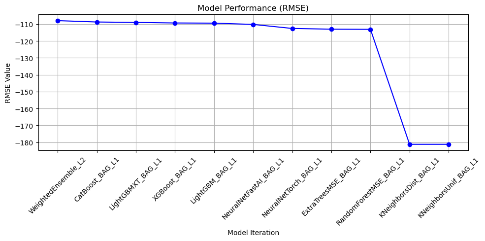

```python
import matplotlib.pyplot as plt

plt.figure(figsize=(10, 5))
plt.plot(model_names, rmse_values, marker='o', linestyle='-', color='b')
plt.title('Model Performance (RMSE)')
plt.xlabel('Model Iteration')
plt.ylabel('RMSE Value')
plt.xticks(rotation=45)  # Rotate model names for better readability
plt.grid(True)
plt.tight_layout()  # Adjust layout to make room for label rotation
plt.show()
```

```python
predictor.model_best
```

```
'WeightedEnsemble_L2'
```

### Create predictions from test dataset

```python
predictions = predictor.predict(test_modified)
predictions.head()
```

```
0    96.547668
1    64.705070
2    64.705070
3    64.796860
4    64.796860
Name: count, dtype: float32
```

```python
#Describe the `predictions` series to see if there are any negative values
predictions.describe()
```

```
count    6493.000000
mean      188.601181
std       146.431625
min         3.375888
25%        77.776047
50%       146.089035
75%       260.166687
max       794.743774
Name: count, dtype: float64
```

```python
# How many negative values do we have?
negative_count = (predictions < 0).sum()
negative_count
```

```
0
```

```python
adjusted_predictions = predictions.clip(lower=0)
```

### Set predictions to submission dataframe, save, and submit

```python
submission_newFeature=submission.copy(deep=True)
```

```python
submission_newFeature["count"] = adjusted_predictions
submission_newFeature.to_csv("submission_newFeatures.csv", index=False)
```

```python
!kaggle competitions submit -c bike-sharing-demand -f submission_newFeatures.csv -m "new features"
```

```
Successfully submitted to Bike Sharing Demand
```

#### View submission via the command line or in the web browser under the competition's page - `My Submissions`

```python
!kaggle competitions submissions -c bike-sharing-demand | tail -n +1 | head -n 6
```

```
fileName                    date                 description           status    publicScore  privateScore
--------------------------  -------------------  --------------------  --------  -----------  ------------
submission_newFeatures.csv  2024-04-29 19:27:24  new features          complete  1.12001      1.12001
submission_initial.csv      2024-04-29 19:26:03  first raw submission  complete  0.52082      0.52082
```

#### New Score of `1.12`

## Step 6: Hyper parameter optimization

- There are many options for hyper parameter optimization.
- Options are to change the AutoGluon higher level parameters or the individual model hyperparameters.
- The hyperparameters of the models themselves that are in AutoGluon. Those need the `hyperparameter` and `hyperparameter_tune_kwargs` arguments.

```python
train_hp=train_modified.copy(deep=True)
```

```python
test_hp=test_modified.copy(deep=True)
```

```python
submission_hp=submission.copy(deep=True)
```

### Remove 'atemp'

```python
train_hp.drop('atemp',axis=1,inplace=True)
```

```python
test_hp.drop('atemp',axis=1,inplace=True)
```

```python
train_hp.info()
```

```
<class 'pandas.core.frame.DataFrame'>
RangeIndex: 10886 entries, 0 to 10885
Data columns (total 22 columns):
 #   Column                           Non-Null Count  Dtype
---  ------                           --------------  -----
 0   holiday                          10886 non-null  int64
 1   workingday                       10886 non-null  int64
 2   count                            10886 non-null  int64
 3   temperature_category_Cold        10886 non-null  int64
 4   temperature_category_Mild        10886 non-null  int64
 5   temperature_category_Hot         10886 non-null  int64
 6   wind_category_Mild Wind          10886 non-null  int64
 7   wind_category_Very Windy         10886 non-null  int64
 8   humidity_category_Not Humid      10886 non-null  int64
 9   humidity_category_Very Humid     10886 non-null  int64
 10  hour_category_Evening Rush Hour  10886 non-null  int64
 11  hour_category_Lunch Rush Hour    10886 non-null  int64
 12  hour_category_Morning Rush Hour  10886 non-null  int64
 13  hour_category_Night              10886 non-null  int64
 14  weather_1                        10886 non-null  int64
 15  weather_2                        10886 non-null  int64
 16  weather_3                        10886 non-null  int64
 17  weather_4                        10886 non-null  int64
 18  season_1                         10886 non-null  int64
 19  season_2                         10886 non-null  int64
 20  season_3                         10886 non-null  int64
 21  season_4                         10886 non-null  int64
dtypes: int64(22)
memory usage: 1.8 MB
```

```python
hyperparameters = {
    'CAT': {
        'learning_rate': 0.01,
        'depth': 6,
        'l2_leaf_reg': 3.5
    }
}

predictor_hp = TabularPredictor(
    label='count',
    eval_metric='rmse',
    path='autogluon_hparameter'
).fit(
    train_data=train_hp,
    time_limit=900,  # Increase time limit for more thorough search
    presets='best_quality',
    hyperparameters=hyperparameters,
    num_stack_levels=2
)
```

```
Presets specified: ['best_quality']
Setting dynamic_stacking from 'auto' to True. Reason: Enable dynamic_stacking when use_bag_holdout is disabled. (use_bag_holdout=False)
Stack configuration (auto_stack=True): num_stack_levels=2, num_bag_folds=8, num_bag_sets=1
Dynamic stacking is enabled (dynamic_stacking=True). AutoGluon will try to determine whether the input data is affected by stacked overfitting and enable or disable stacking as a consequence.
Detecting stacked overfitting by sub-fitting AutoGluon on the input data. That is, copies of AutoGluon will be sub-fit on subset(s) of the data. Then, the holdout validation data is used to detect stacked overfitting.
Sub-fit(s) time limit is: 900 seconds.
Starting holdout-based sub-fit for dynamic stacking. Context path is: autogluon_hparameter/ds_sub_fit/sub_fit_ho.
Running the sub-fit in a ray process to avoid memory leakage.
Spend 206 seconds for the sub-fit(s) during dynamic stacking.
Time left for full fit of AutoGluon: 694 seconds.
Starting full fit now with num_stack_levels 2.
Beginning AutoGluon training ... Time limit = 694s
AutoGluon will save models to "autogluon_hparameter"
=================== System Info ===================
AutoGluon Version:  1.1.0
Python Version:     3.10.6
Operating System:   Linux
Platform Machine:   x86_64
Platform Version:   #1 SMP Sat Mar 23 09:49:55 UTC 2024
CPU Count:          2
Memory Avail:       1.46 GB / 3.78 GB (38.7%)
Disk Space Avail:   8589934590.03 GB / 8589934592.00 GB (100.0%)
===================================================
Train Data Rows:    10886
Train Data Columns: 21
Label Column:       count
Problem Type:       regression
Preprocessing data ...
Using Feature Generators to preprocess the data ...
Fitting AutoMLPipelineFeatureGenerator...
	Available Memory:                    1500.76 MB
	Train Data (Original)  Memory Usage: 1.74 MB (0.1% of available memory)
	Inferring data type of each feature based on column values. Set feature_metadata_in to manually specify special dtypes of the features.
	Stage 1 Generators:
		Fitting AsTypeFeatureGenerator...
			Note: Converting 21 features to boolean dtype as they only contain 2 unique values.
	Stage 2 Generators:
		Fitting FillNaFeatureGenerator...
	Stage 3 Generators:
		Fitting IdentityFeatureGenerator...
```

[output cut: 40 more lines]

```
	0.0s	 = Training   runtime
	0.0s	 = Validation runtime
Fitting 1 L3 models ...
Fitting model: CatBoost_BAG_L3 ... Training model for up to 457.69s of the 457.68s of remaining time.
	Fitting 8 child models (S1F1 - S1F8) | Fitting with ParallelLocalFoldFittingStrategy (2 workers, per: cpus=1, gpus=0, memory=0.62%)
	-119.4459	 = Validation score   (-root_mean_squared_error)
	104.14s	 = Training   runtime
	0.08s	 = Validation runtime
Fitting model: WeightedEnsemble_L4 ... Training model for up to 360.0s of the 348.6s of remaining time.
	Ensemble Weights: {'CatBoost_BAG_L1': 0.467, 'CatBoost_BAG_L2': 0.467, 'CatBoost_BAG_L3': 0.067}
	-118.9496	 = Validation score   (-root_mean_squared_error)
	0.04s	 = Training   runtime
	0.0s	 = Validation runtime
AutoGluon training complete, total runtime = 345.68s ... Best model: "WeightedEnsemble_L4"
TabularPredictor saved. To load, use: predictor = TabularPredictor.load("autogluon_hparameter")
```

```python
predictor_hp.fit_summary()
```

```
*** Summary of fit() ***
Estimated performance of each model:
                 model   score_val              eval_metric  pred_time_val    fit_time  pred_time_val_marginal  fit_time_marginal  stack_level  can_infer  fit_order
0  WeightedEnsemble_L4 -118.949610  root_mean_squared_error       0.292041  327.764742                0.000942           0.035887            4       True          6
1      CatBoost_BAG_L2 -119.168055  root_mean_squared_error       0.214563  223.589094                0.100901         131.843144            2       True          3
2  WeightedEnsemble_L3 -119.168055  root_mean_squared_error       0.215782  223.592863                0.001219           0.003770            3       True          4
3      CatBoost_BAG_L1 -119.210271  root_mean_squared_error       0.113662   91.745949                0.113662          91.745949            1       True          1
4  WeightedEnsemble_L2 -119.210271  root_mean_squared_error       0.114740   91.763711                0.001079           0.017762            2       True          2
5      CatBoost_BAG_L3 -119.445852  root_mean_squared_error       0.291099  327.728855                0.076536         104.139761            3       True          5
Number of models trained: 6
Types of models trained:
{'StackerEnsembleModel_CatBoost', 'WeightedEnsembleModel'}
Bagging used: True  (with 8 folds)
Multi-layer stack-ensembling used: True  (with 4 levels)
Feature Metadata (Processed):
(raw dtype, special dtypes):
('int', ['bool']) : 21 | ['holiday', 'workingday', 'temperature_category_Cold', 'temperature_category_Mild', 'temperature_category_Hot', ...]
Plot summary of models saved to file: autogluon_hparameterSummaryOfModels.html
*** End of fit() summary ***
```

[output not shown]

[output cut: 25 more lines]

```
      fit_time  pred_time_val_marginal  fit_time_marginal  stack_level  \
 0  327.764742                0.000942           0.035887            4
 1  223.589094                0.100901         131.843144            2
 2  223.592863                0.001219           0.003770            3
 3   91.745949                0.113662          91.745949            1
 4   91.763711                0.001079           0.017762            2
 5  327.728855                0.076536         104.139761            3

    can_infer  fit_order
 0       True          6
 1       True          3
 2       True          4
 3       True          1
 4       True          2
 5       True          5  }
```

```python
leaderboard_hp = predictor_hp.leaderboard(silent=True)
```

```python
model_names = leaderboard_hp['model']
rmse_values = leaderboard_hp['score_val']
```

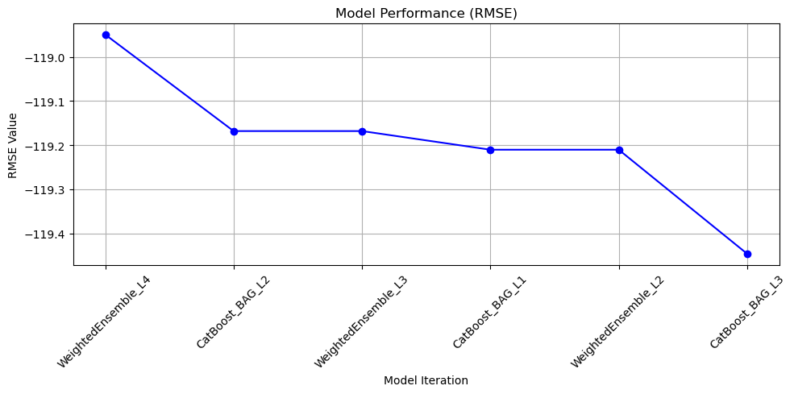

```python
import matplotlib.pyplot as plt

plt.figure(figsize=(10, 5))
plt.plot(model_names, rmse_values, marker='o', linestyle='-', color='b')
plt.title('Model Performance (RMSE)')
plt.xlabel('Model Iteration')
plt.ylabel('RMSE Value')
plt.xticks(rotation=45)
plt.grid(True)
plt.tight_layout()
plt.show()
```

```python
predictions_hp = predictor_hp.predict(test_modified)
predictions_hp.head()
```

```
0    134.060547
1    121.128143
2    121.128143
3    121.128143
4    121.128143
Name: count, dtype: float32
```

```python
predictions_hp.describe()
```

```
count    6493.000000
mean      189.331757
std       136.997345
min        16.227686
25%        86.129913
50%       145.408798
75%       248.980011
max       705.905273
Name: count, dtype: float64
```

```python
# Same submitting predictions
submission_hp["count"] = predictions_hp
submission_hp.to_csv("submission_new_hpo.csv", index=False)
```

```python
!kaggle competitions submit -c bike-sharing-demand -f submission_new_hpo.csv -m "new features with hyperparameters"
```

```
Successfully submitted to Bike Sharing Demand
```

```python
!kaggle competitions submissions -c bike-sharing-demand | tail -n +1 | head -n 6
```

```
fileName                    date                 description                        status    publicScore  privateScore
--------------------------  -------------------  ---------------------------------  --------  -----------  ------------
submission_new_hpo.csv      2024-04-29 20:17:07  new features with hyperparameters  complete  1.18811      1.18811
submission_newFeatures.csv  2024-04-29 19:27:24  new features                       complete  1.12001      1.12001
submission_initial.csv      2024-04-29 19:26:03  first raw submission               complete  0.52082      0.52082
```

### Using hyperparameter_tune_kwargs

```python
train_khp=train_hp.copy(deep=True)
```

```python
test_khp=test_hp.copy(deep=True)
```

```python
submission_khp=submission.copy(deep=True)
```

```python
from autogluon.tabular import TabularPredictor

# Define hyperparameter tuning configuration for CatBoost only
hyperparameter_tune_kwargs = {
    'num_trials': 2,                    # Number of trials
    'scheduler': 'local',                # Scheduler type
    'searcher': 'random',                # Search strategy
}

# Configure and fit the predictor focusing on CatBoost model
predictor = TabularPredictor(
    label="count",
    problem_type="regression",
    eval_metric="rmse",
    path='autogluon_hp'
).fit(
    train_data=train_khp,
    time_limit=360,                      # Total time limit for the fitting process
    presets="best_quality",              # Use the best quality settings for model training
    hyperparameters={'CAT': {}},         # Use only CatBoost model for training
    excluded_model_types=['KNN', 'RF', 'XGB', 'LGB', 'NN'], # Exclude other model types to focus on CatBoost
    hyperparameter_tune_kwargs=hyperparameter_tune_kwargs
)
```

```
Presets specified: ['best_quality']
Warning: hyperparameter tuning is currently experimental and may cause the process to hang.
Setting dynamic_stacking from 'auto' to True. Reason: Enable dynamic_stacking when use_bag_holdout is disabled. (use_bag_holdout=False)
Stack configuration (auto_stack=True): num_stack_levels=1, num_bag_folds=8, num_bag_sets=1
Dynamic stacking is enabled (dynamic_stacking=True). AutoGluon will try to determine whether the input data is affected by stacked overfitting and enable or disable stacking as a consequence.
Detecting stacked overfitting by sub-fitting AutoGluon on the input data. That is, copies of AutoGluon will be sub-fit on subset(s) of the data. Then, the holdout validation data is used to detect stacked overfitting.
Sub-fit(s) time limit is: 360 seconds.
Starting holdout-based sub-fit for dynamic stacking. Context path is: autogluon_hp/ds_sub_fit/sub_fit_ho.
Running the sub-fit in a ray process to avoid memory leakage.
Spend 79 seconds for the sub-fit(s) during dynamic stacking.
Time left for full fit of AutoGluon: 281 seconds.
Starting full fit now with num_stack_levels 1.
Beginning AutoGluon training ... Time limit = 281s
AutoGluon will save models to "autogluon_hp"
=================== System Info ===================
AutoGluon Version:  1.1.0
Python Version:     3.10.6
Operating System:   Linux
Platform Machine:   x86_64
Platform Version:   #1 SMP Sat Mar 23 09:49:55 UTC 2024
CPU Count:          2
Memory Avail:       1.84 GB / 3.78 GB (48.8%)
Disk Space Avail:   8589934589.88 GB / 8589934592.00 GB (100.0%)
===================================================
Train Data Rows:    10886
Train Data Columns: 21
Label Column:       count
Problem Type:       regression
Preprocessing data ...
Using Feature Generators to preprocess the data ...
Fitting AutoMLPipelineFeatureGenerator...
	Available Memory:                    1889.34 MB
	Train Data (Original)  Memory Usage: 1.74 MB (0.1% of available memory)
	Inferring data type of each feature based on column values. Set feature_metadata_in to manually specify special dtypes of the features.
	Stage 1 Generators:
		Fitting AsTypeFeatureGenerator...
			Note: Converting 21 features to boolean dtype as they only contain 2 unique values.
	Stage 2 Generators:
		Fitting FillNaFeatureGenerator...
	Stage 3 Generators:
```

[output cut: 9 more lines]

```
	0.1s = Fit runtime
	21 features in original data used to generate 21 features in processed data.
	Train Data (Processed) Memory Usage: 0.22 MB (0.0% of available memory)
Data preprocessing and feature engineering runtime = 0.18s ...
AutoGluon will gauge predictive performance using evaluation metric: 'root_mean_squared_error'
	This metric's sign has been flipped to adhere to being higher_is_better. The metric score can be multiplied by -1 to get the metric value.
	To change this, specify the eval_metric parameter of Predictor()
User-specified model hyperparameters to be fit:
{
	'CAT': {},
}
AutoGluon will fit 2 stack levels (L1 to L2) ...
Excluded models: [] (Specified by `excluded_model_types`)
Fitting 1 L1 models ...
Hyperparameter tuning model: CatBoost_BAG_L1 ... Tuning model for up to 168.45s of the 280.82s of remaining time.
```

```
	Fitting 8 child models (S1F1 - S1F8) | Fitting with ParallelLocalFoldFittingStrategy (2 workers, per: cpus=1, gpus=0, memory=0.49%)
	Fitting 8 child models (S1F1 - S1F8) | Fitting with ParallelLocalFoldFittingStrategy (2 workers, per: cpus=1, gpus=0, memory=0.27%)
Fitted model: CatBoost_BAG_L1/T1 ...
	-119.2024	 = Validation score   (-root_mean_squared_error)
	35.42s	 = Training   runtime
	0.0s	 = Validation runtime
Fitted model: CatBoost_BAG_L1/T2 ...
	-119.2277	 = Validation score   (-root_mean_squared_error)
	26.39s	 = Training   runtime
	0.0s	 = Validation runtime
Fitting model: WeightedEnsemble_L2 ... Training model for up to 280.82s of the 218.72s of remaining time.
	Ensemble Weights: {'CatBoost_BAG_L1/T1': 0.591, 'CatBoost_BAG_L1/T2': 0.409}
	-119.1804	 = Validation score   (-root_mean_squared_error)
	0.01s	 = Training   runtime
	0.0s	 = Validation runtime
Excluded models: [] (Specified by `excluded_model_types`)
Fitting 1 L2 models ...
Hyperparameter tuning model: CatBoost_BAG_L2 ... Tuning model for up to 196.74s of the 218.59s of remaining time.
```

```
	Fitting 8 child models (S1F1 - S1F8) | Fitting with ParallelLocalFoldFittingStrategy (2 workers, per: cpus=1, gpus=0, memory=0.53%)
	Fitting 8 child models (S1F1 - S1F8) | Fitting with ParallelLocalFoldFittingStrategy (2 workers, per: cpus=1, gpus=0, memory=0.31%)
Fitted model: CatBoost_BAG_L2/T1 ...
	-119.1287	 = Validation score   (-root_mean_squared_error)
	39.75s	 = Training   runtime
	0.0s	 = Validation runtime
Fitted model: CatBoost_BAG_L2/T2 ...
	-119.2564	 = Validation score   (-root_mean_squared_error)
	26.66s	 = Training   runtime
	0.0s	 = Validation runtime
Fitting model: WeightedEnsemble_L3 ... Training model for up to 280.82s of the 151.88s of remaining time.
	Ensemble Weights: {'CatBoost_BAG_L2/T1': 0.526, 'CatBoost_BAG_L1/T1': 0.316, 'CatBoost_BAG_L1/T2': 0.158}
	-118.947	 = Validation score   (-root_mean_squared_error)
	0.02s	 = Training   runtime
	0.0s	 = Validation runtime
AutoGluon training complete, total runtime = 129.42s ... Best model: "WeightedEnsemble_L3"
TabularPredictor saved. To load, use: predictor = TabularPredictor.load("autogluon_hp")
```

```python
predictor.fit_summary()
```

```
*** Summary of fit() ***
Estimated performance of each model:
                 model   score_val              eval_metric  pred_time_val    fit_time  pred_time_val_marginal  fit_time_marginal  stack_level  can_infer  fit_order
0  WeightedEnsemble_L3 -118.946984  root_mean_squared_error       0.001309  101.582295                0.000894           0.022431            3       True          6
1   CatBoost_BAG_L2/T1 -119.128688  root_mean_squared_error       0.000415  101.559864                0.000144          39.748096            2       True          4
2  WeightedEnsemble_L2 -119.180406  root_mean_squared_error       0.000980   61.824893                0.000709           0.013125            2       True          3
3   CatBoost_BAG_L1/T1 -119.202431  root_mean_squared_error       0.000141   35.418852                0.000141          35.418852            1       True          1
4   CatBoost_BAG_L1/T2 -119.227665  root_mean_squared_error       0.000130   26.392916                0.000130          26.392916            1       True          2
5   CatBoost_BAG_L2/T2 -119.256408  root_mean_squared_error       0.000402   88.473976                0.000131          26.662208            2       True          5
Number of models trained: 6
Types of models trained:
{'StackerEnsembleModel_CatBoost', 'WeightedEnsembleModel'}
Bagging used: True  (with 8 folds)
Multi-layer stack-ensembling used: True  (with 3 levels)
Feature Metadata (Processed):
(raw dtype, special dtypes):
('int', ['bool']) : 21 | ['holiday', 'workingday', 'temperature_category_Cold', 'temperature_category_Mild', 'temperature_category_Hot', ...]
Plot summary of models saved to file: autogluon_hpSummaryOfModels.html
*** End of fit() summary ***
```

[output not shown]

[output cut: 25 more lines]

```
      fit_time  pred_time_val_marginal  fit_time_marginal  stack_level  \
 0  101.582295                0.000894           0.022431            3
 1  101.559864                0.000144          39.748096            2
 2   61.824893                0.000709           0.013125            2
 3   35.418852                0.000141          35.418852            1
 4   26.392916                0.000130          26.392916            1
 5   88.473976                0.000131          26.662208            2

    can_infer  fit_order
 0       True          6
 1       True          4
 2       True          3
 3       True          1
 4       True          2
 5       True          5  }
```

```python
# Generate the leaderboard
leaderboard = predictor.leaderboard()
best_model_name = leaderboard.iloc[0]['model']
```

```python
leaderboard
```

|  | model | score_val | eval_metric | pred_time_val | fit_time | pred_time_val_marginal | fit_time_marginal | stack_level | can_infer | fit_order |
| --- | --- | --- | --- | --- | --- | --- | --- | --- | --- | --- |
| 0 | WeightedEnsemble_L3 | -118.946984 | root_mean_squared_error | 0.001309 | 101.582295 | 0.000894 | 0.022431 | 3 | True | 6 |
| 1 | CatBoost_BAG_L2/T1 | -119.128688 | root_mean_squared_error | 0.000415 | 101.559864 | 0.000144 | 39.748096 | 2 | True | 4 |
| 2 | WeightedEnsemble_L2 | -119.180406 | root_mean_squared_error | 0.000980 | 61.824893 | 0.000709 | 0.013125 | 2 | True | 3 |
| 3 | CatBoost_BAG_L1/T1 | -119.202431 | root_mean_squared_error | 0.000141 | 35.418852 | 0.000141 | 35.418852 | 1 | True | 1 |
| 4 | CatBoost_BAG_L1/T2 | -119.227665 | root_mean_squared_error | 0.000130 | 26.392916 | 0.000130 | 26.392916 | 1 | True | 2 |
| 5 | CatBoost_BAG_L2/T2 | -119.256408 | root_mean_squared_error | 0.000402 | 88.473976 | 0.000131 | 26.662208 | 2 | True | 5 |

```python
predictor_khp = predictor.predict(test_khp)
predictor_khp.head()
```

```
0    132.649139
1    120.477333
2    120.477333
3    120.477333
4    120.477333
Name: count, dtype: float32
```

```python
predictor_khp.describe()
```

```
count    6493.000000
mean      189.616806
std       137.432877
min        12.190766
25%        85.618927
50%       147.456787
75%       247.662415
max       712.608643
Name: count, dtype: float64
```

```python
# Same submitting predictions
submission_khp["count"] = predictor_khp
submission_khp.to_csv("submission_new_khpo.csv", index=False)
```

```python
!kaggle competitions submit -c bike-sharing-demand -f submission_new_hpo.csv -m "new hyperparameters"
```

```
Successfully submitted to Bike Sharing Demand
```

```python
!kaggle competitions submissions -c bike-sharing-demand | tail -n +1 | head -n 6
```

```
fileName                    date                 description                        status    publicScore  privateScore
--------------------------  -------------------  ---------------------------------  --------  -----------  ------------
submission_new_hpo.csv      2024-04-30 21:02:29  new hyperparameters                complete  1.18811      1.18811
submission_new_hpo.csv      2024-04-29 20:17:07  new features with hyperparameters  complete  1.18811      1.18811
submission_newFeatures.csv  2024-04-29 19:27:24  new features                       complete  1.12001      1.12001
submission_initial.csv      2024-04-29 19:26:03  first raw submission               complete  0.52082      0.52082
```